# Curso de introducción a la programación con Python

**Autor: Luis Fernando Apáez Álvarez**

## Proyecto 1 (parte III): Derivadas

- Derivadas
- Derivadas de orden superior
- Graficar rectas tangentes

## Derivadas

Así como trabajamos en el final de la parte II del proyecto con la resolución de límites utilizando el módulo `sympy`, podemos calcular derivadas de la misma manera, lo cual conseguiremos utilizando `diff(y,x)`. Donde `x` es una variable simbólica y `y` una variable que depende de `x`. Por ejemplo, podemos calcular la derivada de la función $f(x)=x^{2}$ la cual es

$$ \frac{d}{dx}f(x)=\frac{d}{dx}x^{2}=2\cdot x $$

Lo cual puede calcularse también utilizando el siguiente código

```python
import numpy as np
from sympy import *

# definimos a x como un símbolo
x = symbols("x")

# definimos la función de interés
y = x ** 2

# calculamos la derivada de y respecto de x
diff(y,x)
```

$\displaystyle 2 x$

Asimismo podemos evaluar la derivada en algún punto, lo cual sabemos que representa (geométricamente) la pendiente de la recta tangente en ese punto; por ejemplo podemos calcular $f'(2)=2(2)=4$ o en código:

```python
# colocaremos .subs(x,2) para efectuar matemáicamente f(2)

diff(y,x).subs(x,2)
```

$\displaystyle 4$

## Derivadas de orden superior

Sabemos que al derivar una función volvemos a obtener otra función, por ello es que a la derivada podemos volver a derivarla obteniéndose así la derivada de segundo orden. Esto es, dada $f(x)$ dos veces derivable, la derivada de orden dos o segunda derivada se define como

$$ \frac{d^{2}}{dx^{2}}f(x)=\frac{d}{dx}\left(\frac{d}{dx}f(x)\right) $$

Por ejemplo, sabemos que $\frac{d}{dx}x^{2}=2x$ y por ende

$$ \frac{d^{2}}{dx^{2}}f(x)=\frac{d}{dx}\left(\frac{d}{dx}x^{2}\right)=\frac{d}{dx}2x=2 $$

En Python agregaremos como tercer parámetro a `diff()` para indicar el orden de la derivada que deseamos calcular. Veamos

```python
# derivada de segundo orden
diff(y,x,2)
```

$\displaystyle 2$

Otro ejemplo interesante es calcular las derivadas de orden superior de la función $g(x)=\frac{1}{x}$:

```python
# definimos la función g(x)
y = 1 / x

# calculamos la primer derivada
diff(y,x)
```

$\displaystyle - \frac{1}{x^{2}}$

```python
# calculamos la segunda derivada
diff(y,x,2)
```

$\displaystyle \frac{2}{x^{3}}$

```python
# calculamos la tercera derivada
diff(y,x,3)
```

$\displaystyle - \frac{6}{x^{4}}$

De tal manera tenemos que $$ \frac{d}{dx}f(x)=-\frac{1}{x^{2}},\ \ \frac{d^{2}}{dx^{2}}f(x)=\frac{2}{x^{3}}, \ \ \frac{d^{3}}{dx^{3}}f(x)=-\frac{6}{x^{4}} $$

Podemos también aplicar la regla de la cadena, por ejemplo podemos derivar la función $h(x)=(sen(x))^{2}$:

```python
import numpy as np

x = symbols("x")

# definimos la función f
f = sin(x)

# definimos la función g que depende de la función f
g = f ** 2

diff(g,x)
```

$\displaystyle 2 \sin{\left(x \right)} \cos{\left(x \right)}$

Derivemos ahora la función $k(x)=ln(sen(x))$ cuya derivada es

$$ \frac{d}{dx}k(x)=\frac{\frac{d}{dx}sen(x)}{sen(x)}=\frac{cos(x)}{sen(x)} $$

o en código

```python
# definimos la función f
f = sin(x)

# definimos la función g que depende de f
g = log(f)

diff(g, x)
```

$\displaystyle \frac{\cos{\left(x \right)}}{\sin{\left(x \right)}}$

además podemos simplificar expresiones algebraicas, para ello utilizamos `simplify()`. Por ejemplo

```python
simplify(diff(g,x))
```

$\displaystyle \frac{1}{\tan{\left(x \right)}}$

## Graficar rectas tangentes

Como bien sabemos, en general, la derivada de $f(x)$ representa la pendiente de la recta tangente a la gráfica de $f(x)$ en el punto $x$. Es decir, si consideramos por ejemplo $f(x)=x^{2}$, y queremos conocer la pendiente de la recta tangente en el punto $x=3$ hacemos la evaluación $f'(3)=2(3)=6$. Obtengamos la ecuación de dicha recta. Sabemos que la ecuación punto-pendiente es de la forma

$$ y-y_{1}=m(x-x_{1}) $$

pero en este caso la pendiente es $f'(3)=6$ y el punto $x_{1}=3$. Para obtener el punto $y_{1}$ basta con considerar $f(x_{1})=f(3)=3^{2}=9$. De tal manera

$$ y-9=6(x-3)=6x-18 $$

[figure not shown]

```python
import matplotlib.pyplot as mplot

# definimos la función f(x)
x = np.arange(-5,5, 0.01)
y = x ** 2

# graficamos la funcion
mplot.plot(x,y, color = "k", label = "$f(x)=x^{2}$")


# definimos la ecuación de la recta tangente v=6u+9, cambiamos u,v por x,y para evitar confuciones
u = np.arange(-2,5, 0.01)
v = 6 * u - 9

# graficamos la recta z=6x-9
mplot.plot(u,v, color = "r", label = "$y=6x-9$")

# graficamos el punto de tangencia
mplot.plot(3,9, marker = "o", color = "k")


mplot.grid()
mplot.legend()
mplot.show()
```

Finalmente, graficaremos varias rectas tangentes por lo que emplearemos un método similiar a la graficación de varios puntos como lo hicimos en límites. Comencemos por dibujar los puntos de interés, esto lo conseguiremos evaluando los puntos de tangencia de nuestro interés en la función $f(x)$. Por ejemplo, si el punto $x=2$ es un punto de interés, obtendremos la coordenada cmpleta evaluando $f(2)=2^{2}$, lo cual se consigue en usando `.subs(x,2)`. Veamos

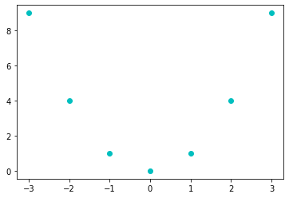

```python
# definimos la función

x = symbols("x")
y = x ** 2

# derivamos
derivada = diff(y,x)

# lista de puntos de tangencia, en este caso serán -3,-2,-1,1,2,3 y 4
puntos_tangencia = [i / 4 for i in range(-12,16,4) if i != 0]

# agregamos el punto de tangencia x=0
puntos_tangencia.append(0)

# graficamos los puntos de tangencia iterando con un bucle for sobre los elementos de la lista de puntos de tangencia
for k in puntos_tangencia:
    mplot.plot(k, y.subs(x,k), marker = "o", color = "c")
```

Después graficaremos las rectas tangentes. Para ello necesitamos

1. Obtener la coordenada $(x_{1},y_{1})$, donde $x_{1}$ es un elemento de la lista `puntos_tangencia` y la ordenada $y_{1}$ se obtiene empleando `y.subs(x,x1)`.
2. Obtener la pendiente de la recta tangente en ese punto, lo cual se consigue usando `derivada.subs(x,x1)`.
3. La ecuación de la recta tangente es de la forma $$ y=m(x-x_{1})+y_{1}=mx-mx_{1}+y_{1} $$

Con base en todo lo anterior tenemos que

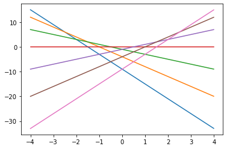

```python
# definimos el dominio de graficación
u = np.arange(-4,4,0.01)

# inicializamos x1 con el primer valor de la lista puntos_tangencia
x1 = -3

# implementamos un bucle while
while x1 in puntos_tangencia:
    y1 = y.subs(x,x1)
    pendiente = derivada.subs(x,x1)
    ecuacion_rec_tangente = pendiente * u - pendiente * x1 + y1
    mplot.plot(u,ecuacion_rec_tangente)
    del y1
    x1 += 1

# es necesario eliminar la variable y1 para que ésta se vuelva a crear en otra iteración y tome el valor
# correspondiente de la x1 en cuestión
mplot.show()
```

Finalmente conjuntamos todo para obtener

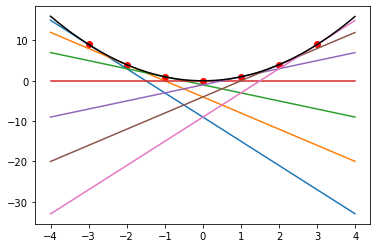

```python
# definimos la función

x = symbols("x")
y = x ** 2

# derivamos
derivada = diff(y,x)

# lista de puntos de tangencia, en este caso serán -3,-2,-1,1,2,3 y 4
puntos_tangencia = [i / 4 for i in range(-12,16,4) if i != 0]

# agregamos el punto de tangencia x=0
puntos_tangencia.append(0)

# graficamos los puntos de tangencia iterando con un bucle for sobre los elementos de la lista de puntos de tangencia
for k in puntos_tangencia:
    mplot.plot(k, y.subs(x,k), marker = "o", color = "r")


# --------------------------------------------------------------------------------------------------------------------


# definimos el dominio de graficación
u = np.arange(-4,4,0.01)

# inicializamos x1 con el primer valor de la lista puntos_tangencia
x1 = -3

# implementamos un bucle while
while x1 in puntos_tangencia:
    y1 = y.subs(x,x1)
    pendiente = derivada.subs(x,x1)
    ecuacion_rec_tangente = pendiente * u - pendiente * x1 + y1
    mplot.plot(u,ecuacion_rec_tangente)
    del y1
    x1 += 1

# es necesario eliminar la variable y1 para que ésta se vuelva a crear en otra iteración y tome el valor
# correspondiente de la x1 en cuestión

# graficamos la función f(x)=x^2

v = np.arange(-4,4,0.01)
w = v ** 2
mplot.plot(v,w, color = "k")

mplot.show()
```